# Weather and Bike Rentals

Oct 2018

- different font for latex formulas?

## Dataset(s)

Two datasets were used: **Bike sharing data**…

- **BIXI Montreal public bicycle sharing system**, North America’s first large-scale bike sharing system
- Available via kaggle from  
  https://www.kaggle.com/aubertsigouin/biximtl/home
- For years \(2014\) to \(2017\)
- Contains **individual records of bike trips**: timestamp and station code for start and end of trip, duration
- \(n = 14598961\) records (individual bike trips)
- Station codes, names, and position (latitude, longitude) available in separate files, but only of secondary interest for this analysis

…and **weather data** from the Canadian government:

- Available from  
  http://climate.weather.gc.ca/ historical_data/  
  search_historic_data_e.html
- API for **bulk data download**:  
  http://climate.weather.gc.ca/climate_data/  
  bulk_data_e.html
- Data can be downloaded per weather station per month and contains **hourly measurements** of different metrics (e.g., timestamp, temperature, relative humidity, atmospheric pressure, wind speed; different measures available for different stations)
- \(n = 35064\) hourly weather records in total (between \(672\) and \(744\) per monthly file)

## Research Question(s)

The research questions that I wanted to answer with my analysis were:

- **To what extent do** the number of **bike rides depend on the current weather conditions**? That is, how well can the number of bike rides be predicted from weather data (and time of year, time of day)?
- What are the **most important factors** that influence the number of bike rides?
- **How do these factors influence** the number of bike rides?

## Methods

First, some **data exploration** was performed, in order to get to know the data and to find out how the number of hourly bike trips is distributed across the investigated time span. Also, the interrelation of features was investigated by means of a correlation heatmap.

In order to find out how well the number of bike rides can be predicted from the data, different models were used As a **baseline model**, a moving average was calculated to find out how this very simple model can explain the data.

## Findings: Data Exploration

**Choosing the closest weather station:**

The Canadian government’s past weather and climate service offers a *search by proximity* function. Via this service, some sample data of the closest stations to Montreal were downloaded. Each of the data files contains information about the weather stations, including the geographical position (latitude and longitude). These coordinates were plotted on a map (see Figure on the right), and the closest station to the bulk of the data was chosen (station name: *MCTAVISH*). Only data from this station was used.

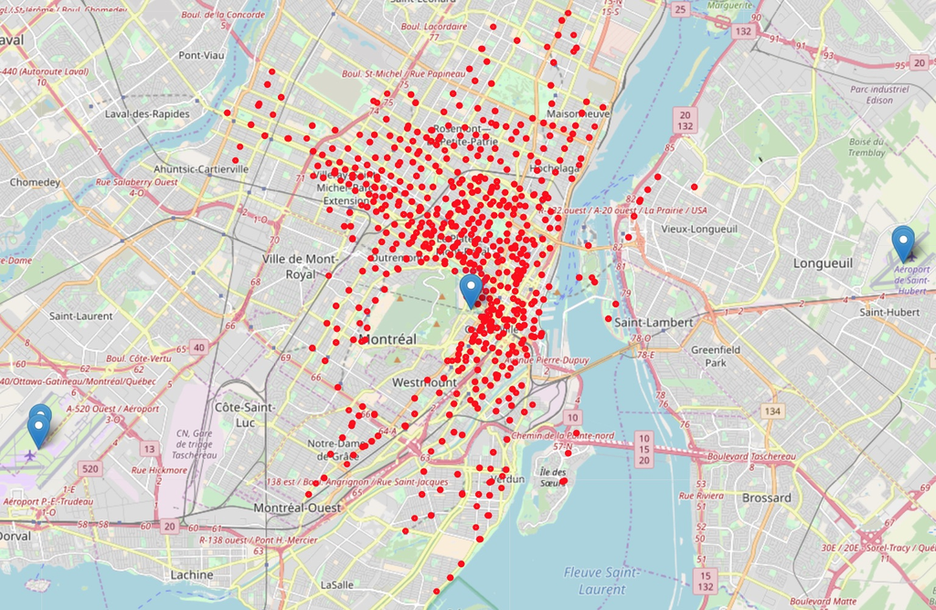

**Figure**: Plot shows all starting stations of a bike trip (red dots), as well as the closest weather stations (blue markers). The closest station in the center is the *MCTAVISH* weather station (Climate Identifier 7024745, WMO Identifier 71612)

## Findings: Data Exploration

To get a better understanding of the data, the number of hourly bike trips was visualized for the time span between \(2014\) and \(2017\).

The moving average that is shown in the plot (red line) can be interpreted as a *baseline model*, i.e., the simplest possible model to describe the hourly number of bike rides.

This baseline model explains \(38.8\%\) of the variance \((r^2 = 0.388)\) and has a mean absolute error of \(MAE = 316.2\), which means that on average, the “prediction” for the number of hourly bike rides is wrong by this many bike rides. This includes also winter months with no rides. For a more realistic estimation of model quality, these numbers drop to \(r^2 = .079\) and \(MAE = 510.7\) when only considering the time frame from May to September.

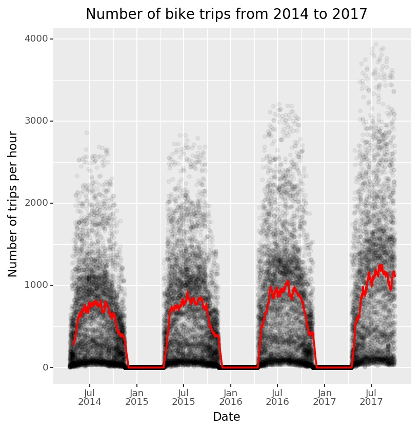

**Figure**: Number of hourly rides from \(2014\) to \(2017\). Each dot represents the number of trips in one specifc hour. Red line represents a moving average using a window of \(14\) days.

## Findings: Data Exploration

To visualize the relations between the available features, a correlation heatmap is shown on the right. The features are only slightly correlated, with the only exception being temperature and dew point that show an almost perfect (linear) relationship \((r = .93)\).

To avoid problems resulting from this multicollinearity, only temperature was used as a predictor, and dew point was dropped. Despite the fact that that gradient boosting is less influenced by multicollinearity, it might still influence calculations of variable importance [2,3].

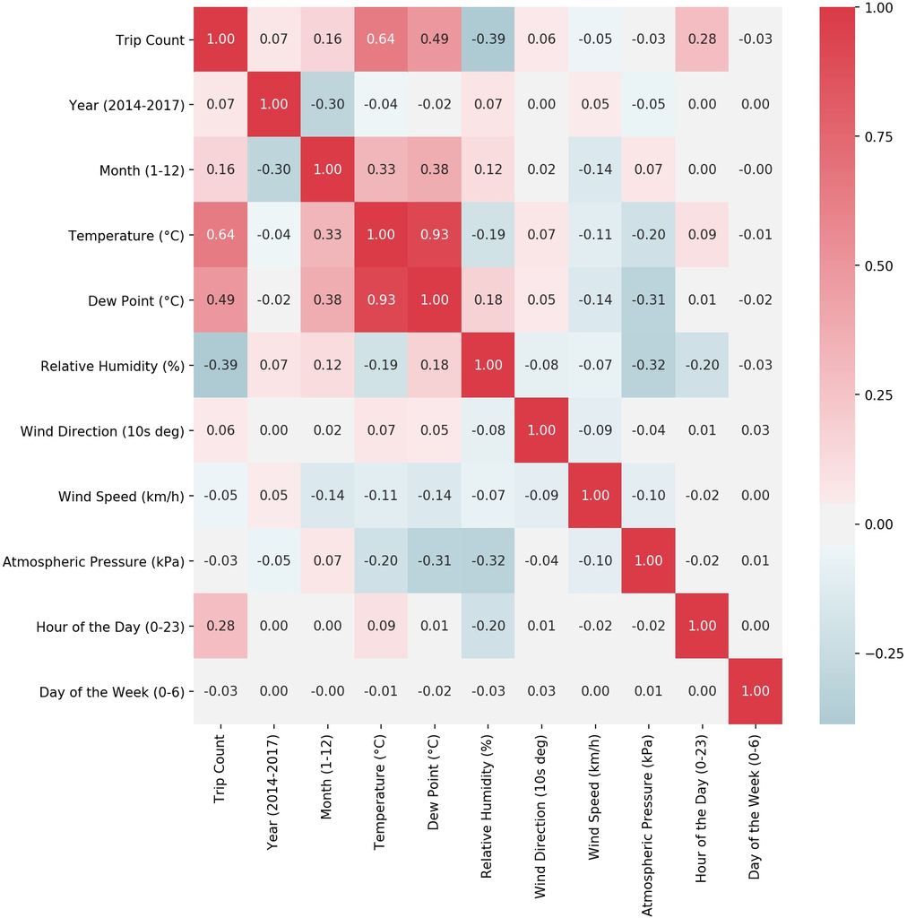

**Figure**: Pearson Correlations between available features in the data.

## Findings: Model Fit

**Table**: Model performance measures for different models. \(r^2\) is the amount of variance explained, \(MAE\) stands for mean absolute error. \(train\) and \(test\) specify training and testing set, respectively. For the test set, some performance measures were also re-computed for using only the summer months of the test set (May to September), indicated via the \(summer\) subscripts.

| Model | \(r^2_{train}\) | \(r^2_{test}\) | \(r^2_{summer}\) | \(MAE_{test}\) | \(MAE_{summer}\) |
| --- | --- | --- | --- | --- | --- |
| Gradient Boosting (XGBoost) | \(0.889\) | \(0.860\) | NA | \(158.0\) | NA |
| Random Forest | \(0.913\) | \(0.894\) | NA | \(111.2\) | NA |
| Gradient Boosting (sklearn) | \(0.997\) | \(0.941\) | \(0.933\) | \(85.4\) | \(105.4\) |

The explained variance of the different models tried ranged from \(r_{test}^2 = 0.860\) to \(r_{test}^2 = 0.941\) for the final model (all in the test set; see table). The hyperparameters for the final model (gradient boosting via scikit-learn) were selected via randomized search using \(4\)-fold cross validation (using only the training set).

The final model fits the data very well, explaining \(94.1\%\) of the variance and exhibiting an average error of \(85.4\) rides over all hourly predictions. This error only increases to \(105.4\) if only summer months are considered.

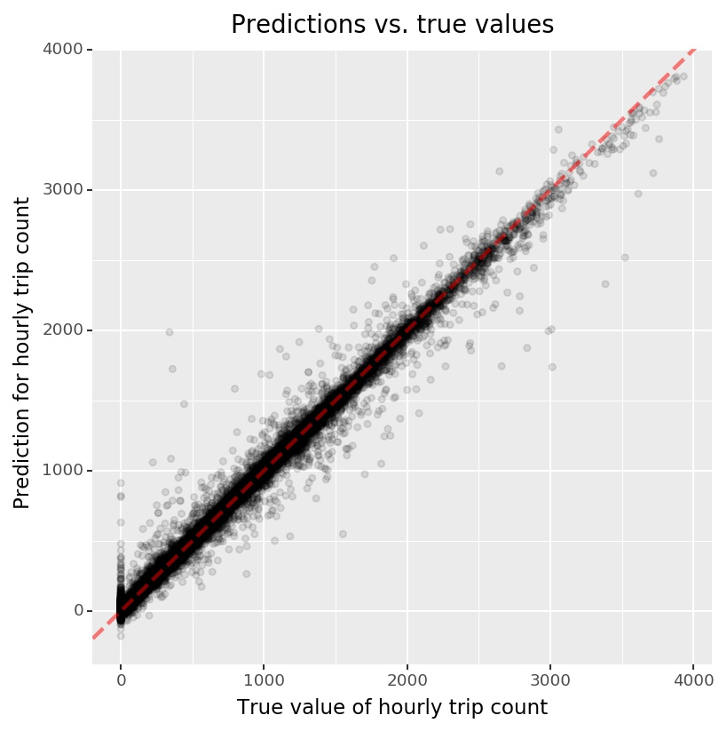

**Figure**: The figure shows actual (true) values vs. predicted values for the number of hourly bike trips for the final model. A perfect model would yield predictions that are identical to the true values, i.e., all points would be on the \(45°\) diagonal. This model is relatively close.

## Findings: Most Important Features

The most important features that influenced the prediciton of hourly bike rides were temperature and atmospheric pressure. While the former is easily comprehensible, the latter is best understood as a proxy for precipitation, which was not available from the weather data: low pressure is commonly related to rainy weather [4]. While Relative humidity is not as tightly connected to rain [5], it interacts with temperature, e.g., it influences how (high) temperatures are perceived [6].

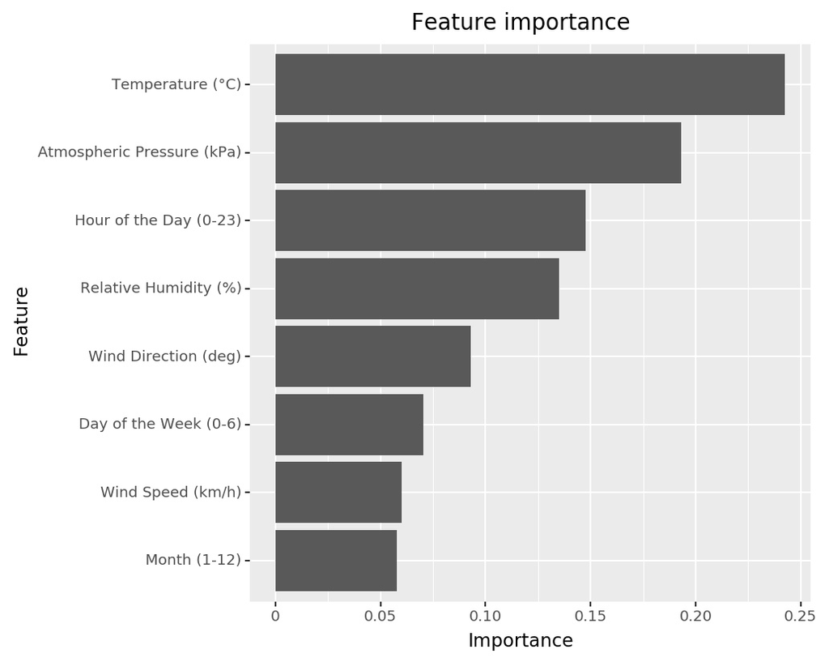

## Limitations

- Results only valid for cities with roughly the same climate.
- Bike rides might be influenced by weather *predictions* for a given day, not only by the actual weather.
- Precipitation (rain, snow) might also be a very good predictor; unfortunately, this was not easily available for the given weather station.
- Maybe have slightly overfitted the training data, but still a good result (MAE).
- Missing values: ignored / imputed?
- Using time and month also, or only weather data?

## References

1. Goldstein A, Kapelner A, Bleich J, Pitkin E. Peeking Inside the Black Box: Visualizing Statistical Learning with Plots of Individual Conditional Expectation [Internet]. 2014. Available: https://arxiv.org/pdf/1309.6392.pdf

2. Wheatley J. Random forest or gradient boosting? [Internet]. 2014. Available: http://joewheatley.net/random-forest-or-gradient-boosting/

3. Parr T, Turgutlu K, Csiszar C, Howard J. Beware Default Random Forest Importances [Internet]. 2018. Available: http://explained.ai/rf-importance/index.html

4. Morgan L. Why Does it Rain When the Pressure Is Low? [Internet]. 2017. Available: https://sciencing.com/rain-pressure-low-8738476.html

5. Haby J. RELATIVE HUMIDITY PITFALLS [Internet]. Available: http://www.theweatherprediction.com/habyhints2/564/

6. Dotson JD. How Temperature & Humidity are Related [Internet]. 2018. Available: https://sciencing.com/temperature-ampamp-humidity-related-7245642.html